```python
# Computations
import numpy as np
import pandas as pd

# sklearn
from sklearn.metrics import confusion_matrix
from sklearn.model_selection import train_test_split, GridSearchCV, RandomizedSearchCV, cross_val_score, KFold
from sklearn.preprocessing import LabelBinarizer, LabelEncoder

# keras
import keras
from keras.models import Sequential
from keras.layers import Dense, Dropout, Activation
from keras.optimizers import SGD, Adagrad
from keras.utils.vis_utils import plot_model
import keras.backend as K
from keras.preprocessing import text, sequence
from keras.utils import to_categorical

# Text
from colorama import Fore, Back, Style
import re
import us
import pgeocode

# Visualisation libraries
import seaborn as sns

import matplotlib.pyplot as plt
from matplotlib.patches import Ellipse, Polygon
import matplotlib.gridspec as gridspec

import missingno as msno

from plotly.offline import init_notebook_mode, iplot
import plotly.graph_objs as go
import plotly.offline as py
from wordcloud import WordCloud
from plotly.subplots import make_subplots
import plotly.express as px

# Graphics in retina format
%config InlineBackend.figure_format = 'retina'

# sns setting
sns.set_context("paper", rc={"font.size":12,"axes.titlesize":14,"axes.labelsize":12})
sns.set_style("whitegrid")

# plt setting
plt.style.use('seaborn-whitegrid')
plt.rcParams['axes.labelsize'] = 14
plt.rcParams['xtick.labelsize'] = 12
plt.rcParams['ytick.labelsize'] = 12
plt.rcParams['text.color'] = 'k'
%matplotlib inline
import warnings
warnings.filterwarnings("ignore")
```

# Consumer Finance Complaints Analyzing and Modeling (using Keras Text Classification)

In this article, we use the [Consumer Complaint Database](https://catalog.data.gov/dataset/consumer-complaint-database) published by [Consumer Financial Protection Bureau](https://catalog.data.gov/dataset?publisher=Consumer%20Financial%20Protection%20Bureau).

## Data Description

According to [Kaggle page](https://www.kaggle.com/cfpb/us-consumer-finance-complaints) ofd Consumer Financial Protection Bureau (CFPB), Each week the [CFPB](https://www.consumerfinance.gov/) sends thousands of consumers’ complaints about financial products and services to companies for response. Those complaints are published here after the company responds or after 15 days, whichever comes first. By adding their voice, consumers help improve the financial marketplace.

```python
Data = pd.read_csv('Data/complaints.csv')
Data.head(3)
```

|  | Date received | Product | Sub-product | Issue | Sub-issue | Consumer complaint narrative | Company public response | Company | State | ZIP code | Tags | Consumer consent provided? | Submitted via | Date sent to company | Company response to consumer | Timely response? | Consumer disputed? | Complaint ID |
| --- | --- | --- | --- | --- | --- | --- | --- | --- | --- | --- | --- | --- | --- | --- | --- | --- | --- | --- |
| 0 | 2019-09-24 | Debt collection | I do not know | Attempts to collect debt not owed | Debt is not yours | transworld systems inc. \nis trying to collect... | NaN | TRANSWORLD SYSTEMS INC | FL | 335XX | NaN | Consent provided | Web | 2019-09-24 | Closed with explanation | Yes | NaN | 3384392 |
| 1 | 2019-09-19 | Credit reporting, credit repair services, or o... | Credit reporting | Incorrect information on your report | Information belongs to someone else | NaN | Company has responded to the consumer and the ... | Experian Information Solutions Inc. | PA | 15206 | NaN | Consent not provided | Web | 2019-09-20 | Closed with non-monetary relief | Yes | NaN | 3379500 |
| 2 | 2019-10-25 | Credit reporting, credit repair services, or o... | Credit reporting | Incorrect information on your report | Information belongs to someone else | I would like to request the suppression of the... | Company has responded to the consumer and the ... | TRANSUNION INTERMEDIATE HOLDINGS, INC. | CA | 937XX | NaN | Consent provided | Web | 2019-10-25 | Closed with explanation | Yes | NaN | 3417821 |

# Data Analysis

## Consumer Complaints by Date Received

```python
Feat= 'Date received'
Group = Data[Feat].value_counts().to_frame('Count').sort_index().reset_index().rename(columns = {'index': Feat})

fig = px.line(Group, x= Feat, y='Count', title='Consumer Complaints by %s' % Feat.title())
fig.update_layout(xaxis_title= Feat.title())
fig.update_xaxes(rangeslider_visible=True)
fig.update_layout(plot_bgcolor= 'WhiteSmoke')
fig['layout']['yaxis'].update(range=[0, 4e3])
fig.show()
```

[interactive chart not shown]

As can be seen, the number of complaints has been increasing overall.

## Consumer Complaints by Product

```python
Feat= 'Product'
Group = Data[Feat].value_counts().to_frame('Count').sort_index().reset_index().rename(columns = {'index': Feat})
Group['Percentage'] = np.round(100*(Group['Count']/Group['Count'].sum()),3)
display(Group.sort_values(by=['Percentage'], ascending = False).\
        style.background_gradient(cmap='Reds', subset=['Percentage']).set_precision(4))
fig = px.bar(Group, y= Feat, x= 'Percentage', orientation='h',text = 'Count',
             title='Consumer Complaints by %s' % Feat.title())
fig.update_traces(marker_color='orange', marker_line_color='DarkRed', marker_line_width=1.5, opacity=1)
fig.update_traces(texttemplate='%{text:.2s}', textposition='outside')
fig.update_layout(uniformtext_minsize=8, uniformtext_mode='hide', height= 700)
fig['layout']['xaxis'].update(range=[0, 30])
fig.update_layout(plot_bgcolor= 'white')
fig.update_xaxes(showgrid=True, gridwidth=1, gridcolor='Lightgray')
fig.update_xaxes(showline=True, linewidth=1, linecolor='Lightgray', mirror=True)
fig.update_yaxes(showline=True, linewidth=1, linecolor='Lightgray', mirror=True)
fig.show()
```

|  | Product | Count | Percentage |
| --- | --- | --- | --- |
| 6 | Credit reporting, credit repair services, or other personal consumer reports | 381290 | 24.2270 |
| 10 | Mortgage | 300314 | 19.0820 |
| 7 | Debt collection | 290394 | 18.4510 |
| 5 | Credit reporting | 140432 | 8.9230 |
| 3 | Credit card | 89190 | 5.6670 |
| 0 | Bank account or service | 86206 | 5.4770 |
| 4 | Credit card or prepaid card | 74134 | 4.7100 |
| 1 | Checking or savings account | 61933 | 3.9350 |
| 15 | Student loan | 57631 | 3.6620 |
| 2 | Consumer Loan | 31604 | 2.0080 |
| 16 | Vehicle loan or lease | 16766 | 1.0650 |
| 8 | Money transfer, virtual currency, or money service | 15266 | 0.9700 |
| 13 | Payday loan, title loan, or personal loan | 12886 | 0.8190 |
| 12 | Payday loan | 5543 | 0.3520 |
| 9 | Money transfers | 5354 | 0.3400 |
| 14 | Prepaid card | 3819 | 0.2430 |
| 11 | Other financial service | 1059 | 0.0670 |
| 17 | Virtual currency | 18 | 0.0010 |

[interactive chart not shown]

## Consumer Complaints by State

```python
Feat= 'State'
Group = Data[Feat].value_counts().to_frame('Count').sort_index().reset_index().rename(columns = {'index': Feat})
fig = go.Figure(data=go.Choropleth(locations = Group[Feat],
                                   z = Group['Count'].astype(float),
                                   locationmode = 'USA-states',
                                   colorscale = 'Reds',
                                   colorbar_title = 'Number of<br>Consumer<br>Complaints' ))
fig.update_layout(title_text = 'Consumer Complaints by %s' % Feat.title(),
                  geo_scope='usa')
fig.show()

Group['Percentage'] = np.round(100*(Group['Count']/Group['Count'].sum()),3)
Group = Group.replace(us.states.mapping('abbr', 'name'))
Group.loc[Group.State.isin(['AA', 'AE', 'AP', 'FM', 'MH', 'PW',
                            'UNITED STATES MINOR OUTLYING ISLANDS']), 'State'] = 'Other States'
Group = Group.sort_values(by=Feat)

fig = px.bar(Group, x= Feat, y= 'Percentage', text = 'Count', title='Consumer Complaints by %s' % Feat.title())
fig.update_traces(marker_color='DarkOrchid', marker_line_color='Indigo', marker_line_width=1.5, opacity=1)
fig.update_traces(texttemplate='%{text:.2s}', textposition='outside')
fig.update_layout(uniformtext_minsize=8, uniformtext_mode='hide', height= 700)
fig['layout']['yaxis'].update(range=[0, 16])
fig.update_layout(plot_bgcolor= 'white')
fig.update_yaxes(showgrid=True, gridwidth=1, gridcolor='Lightgray')
fig.update_xaxes(showline=True, linewidth=1, linecolor='Lightgray', mirror=True)
fig.update_yaxes(showline=True, linewidth=1, linecolor='Lightgray', mirror=True)
fig.show()
```

[interactive chart not shown]

The top ten states with the highest numbers of complaints can be found in the following table.

```python
display(Group.sort_values(by=['Percentage'], ascending = False)[:10].\
        style.hide_index().background_gradient(cmap='Reds', subset=['Percentage']).set_precision(4))
```

| State | Count | Percentage |
| --- | --- | --- |
| California | 212953 | 13.7640 |
| Florida | 165244 | 10.6810 |
| Texas | 134235 | 8.6760 |
| New York | 107450 | 6.9450 |
| Georgia | 84399 | 5.4550 |
| Illinois | 59893 | 3.8710 |
| New Jersey | 56847 | 3.6740 |
| Pennsylvania | 54302 | 3.5100 |
| North Carolina | 48286 | 3.1210 |
| Ohio | 45959 | 2.9710 |

## Complain Sent to Companies

```python
Data['Date received'] = pd.to_datetime(Data['Date received'])
Data['Date sent to company'] = pd.to_datetime(Data['Date sent to company'])
Group = (Data['Date sent to company'] - Data['Date received'])
Group = Group .value_counts().to_frame('Count').reset_index(drop = False).rename(columns = {'index':'Days'})
Group['Days'] = (Group['Days']/ np.timedelta64(1, 'D')).astype(int)
Group.loc[Group['Days']<0, 'Days'] =0
Group = Group.sort_values(by=['Days'])

fig = px.line(Group, x= 'Days', y='Count', title='Consumer Complaint Sent to Company')
fig.update_layout(xaxis_title= Feat.title())
fig.update_xaxes(rangeslider_visible=True)
fig.update_layout(plot_bgcolor= 'WhiteSmoke')
fig['layout']['yaxis'].update(range=[0, 1.2e6])
fig.update_layout(xaxis_title= 'Days After Complain Received')
fig.show()
```

[interactive chart not shown]

## Disputed Complains

```python
Temp = ['Company response to consumer','Timely response?', 'Consumer disputed?']
Group = Data[Temp].groupby(Temp)[[Temp[0]]].agg('count').rename(columns = {Temp[0]:'Count'}).reset_index(drop = False)
Group['Label'] = np.nan
Group.loc[Group['Timely response?'] == 'Yes', 'Label'] = Group['Company response to consumer'] + ' (Timely response)'
Group.loc[Group['Timely response?'] == 'No', 'Label'] = Group['Company response to consumer'] + ' (Not Timely response)'
Group['Percentage'] = np.round(100* Group['Count'] /Group['Count'].sum(), 2)

C = ['aquamarine', 'steelblue']
SC = 'Navy'
fig = px.bar(Group, x= 'Percentage', y= 'Label', orientation='h',
             color = 'Consumer disputed?', text = 'Percentage', color_discrete_sequence= C, height= 500)
fig.update_traces(marker_line_color=SC, marker_line_width=1.5, opacity=1)
fig.update_traces(texttemplate='%{text:.2}', textposition='inside')
fig.update_layout(uniformtext_minsize= 8, uniformtext_mode='hide')
fig['layout']['xaxis'].update(range=[0, 100])
fig.update_layout(title = """Customers' Complains by Companies""", plot_bgcolor= 'white')
fig.update_xaxes(showgrid=True, gridwidth=1, gridcolor='Lightgray')
fig.update_xaxes(showline=True, linewidth=1, linecolor='Lightgray', mirror=True)
fig.update_yaxes(showline=True, linewidth=1, linecolor='Lightgray', mirror=True)
fig.update_layout(yaxis_title= 'Company Response to Consumer')
fig.show()
```

[interactive chart not shown]

# Problem Description

The object of the exercise here is to link the narrative of a complaint with the product. For this reason, we would like to use a form of text processing and combine Keras artificial neural network (ANN) for creating a predictive model.

# Modeling

```python
def Data_info(Inp, Only_NaN = False):
    Out = Inp.dtypes.to_frame(name='Data Type').sort_values(by=['Data Type'])
    Out = Out.join(Inp.isnull().sum().to_frame(name = 'Number of NaN Values'), how='outer')
    Out['Percentage'] = np.round(100*(Out['Number of NaN Values']/Inp.shape[0]),2)
    if Only_NaN:
        Out = Out.loc[Out['Number of NaN Values']>0]
    return Out

Data_info(Data)
```

|  | Data Type | Number of NaN Values | Percentage |
| --- | --- | --- | --- |
| Company | object | 0 | 0.00 |
| Company public response | object | 976613 | 62.05 |
| Company response to consumer | object | 1 | 0.00 |
| Complaint ID | int64 | 0 | 0.00 |
| Consumer complaint narrative | object | 1052704 | 66.89 |
| Consumer consent provided? | object | 633534 | 40.25 |
| Consumer disputed? | object | 805362 | 51.17 |
| Date received | datetime64[ns] | 0 | 0.00 |
| Date sent to company | datetime64[ns] | 0 | 0.00 |
| Issue | object | 0 | 0.00 |
| Product | object | 0 | 0.00 |
| State | object | 26691 | 1.70 |
| Sub-issue | object | 566062 | 35.97 |
| Sub-product | object | 235165 | 14.94 |
| Submitted via | object | 0 | 0.00 |
| Tags | object | 1358856 | 86.34 |
| Timely response? | object | 0 | 0.00 |
| ZIP code | object | 149390 | 9.49 |

However, we need to focus only on **Consumer complaint narrative** and **Product** features. Therefore,

```python
df = Data[['Consumer complaint narrative', 'Product']]
df = df.dropna(subset=['Consumer complaint narrative'])
display(df.head(5))
display(df.isnull().sum().to_frame('Number of NaN Values'))
```

|  | Consumer complaint narrative | Product |
| --- | --- | --- |
| 0 | transworld systems inc. \nis trying to collect... | Debt collection |
| 2 | I would like to request the suppression of the... | Credit reporting, credit repair services, or o... |
| 3 | Over the past 2 weeks, I have been receiving e... | Debt collection |
| 8 | XX/XX/2020 : Sent letter to original creditor ... | Credit reporting, credit repair services, or o... |
| 11 | I was sold access to an event digitally, of wh... | Money transfer, virtual currency, or money ser... |

|  | Number of NaN Values |
| --- | --- |
| Consumer complaint narrative | 0 |
| Product | 0 |

First, we need to do text tokenization. This can be done using [Keras preprocessing text tokenizer](https://www.tensorflow.org/api_docs/python/tf/keras/preprocessing/text/Tokenizer).

```python
tokenize = text.Tokenizer(num_words= 1000, char_level=False)

# Train and Test sets
train, test= train_test_split(df, test_size=0.3, random_state=42)

# X_train, X_test
tokenize.fit_on_texts(train['Consumer complaint narrative'])
X_train = tokenize.texts_to_matrix(train['Consumer complaint narrative'])
X_test = tokenize.texts_to_matrix(test['Consumer complaint narrative'])

# y_train, y_test
encoder = LabelEncoder()
encoder.fit(df['Product'])
y_train = encoder.transform(train['Product'])
y_test = encoder.transform(test['Product'])
```

Moreover, categorical variables can be converted into indicator variables using [tf.keras.utils.to_categorical](https://www.tensorflow.org/api_docs/python/tf/keras/utils/to_categorical).

```python
num_classes = len(np.unique(y_train))
y_train = to_categorical(y_train, num_classes)
y_test = to_categorical(y_test, num_classes)

pd.DataFrame(data={'Set':['X_train','X_test','y_train','y_test'],
                   'Shape':[X_train.shape, X_test.shape, y_train.shape, y_test.shape]}).set_index('Set').T
```

| Set | X_train | X_test | y_train | y_test |
| --- | --- | --- | --- | --- |
| Shape | (364794, 1000) | (156341, 1000) | (364794, 18) | (156341, 18) |

For this study, we use the [Sequential model](https://keras.io/getting-started/sequential-model-guide/), which is a linear stack of layers.

```
Model: "sequential_1"
_________________________________________________________________
Layer (type)                 Output Shape              Param #
=================================================================
dense_1 (Dense)              (None, 512)               512512
_________________________________________________________________
dense_2 (Dense)              (None, 128)               65664
_________________________________________________________________
dense_3 (Dense)              (None, 64)                8256
_________________________________________________________________
dense_4 (Dense)              (None, 18)                1170
=================================================================
Total params: 587,602
Trainable params: 587,602
Non-trainable params: 0
_________________________________________________________________
```

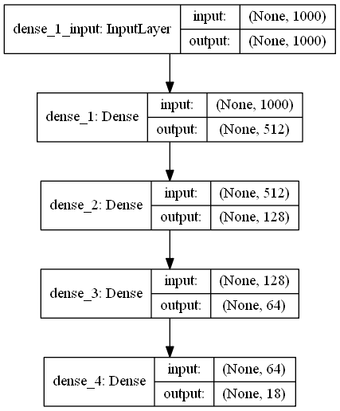

```python
model = Sequential()
model.add(Dense(512, input_dim= X_train.shape[1], init='uniform', activation='relu'))
model.add(Dense(128, init='uniform', activation='sigmoid'))
model.add(Dense(64, init='uniform', activation='sigmoid'))
model.add(Dense(y_train.shape[1], init='uniform', activation='sigmoid'))
model.summary()
plot_model(model, show_shapes=True, show_layer_names=True, expand_nested = True)
```

```python
# Number of iterations
IT = 6

model.compile(optimizer='rmsprop', loss='categorical_crossentropy', metrics=['accuracy','mae', 'mse'])

# Train model
history = model.fit(X_train, y_train, nb_epoch= IT, batch_size=32,  verbose=0)
# Predications and Score
y_pred = model.predict(X_test)
score = model.evaluate(X_test, y_test)
```

```python
score = pd.DataFrame(score, index = model.metrics_names).T
history = pd.DataFrame(history.history)
display(score.style.hide_index())
```

| loss | accuracy | mae | mse |
| --- | --- | --- | --- |
| 0.790631 | 0.752662 | 0.055556 | 0.055556 |

```python
fig = go.Figure()
fig.add_trace(go.Scatter(x= history.index.values, y= history['loss'].values, line=dict(color='OrangeRed', width= 1.5),
                         name = 'Loss'))
fig.add_trace(go.Scatter(x= history.index.values, y= history['accuracy'].values, line=dict(color='MidnightBlue', width= 1.5),
                         name = 'Accuracy'))
fig.add_trace(go.Scatter(x= history.index.values, y= history['mae'].values, line=dict(color='ForestGreen', width= 1.5),
                         name = 'Mean Absolute Error (MAE)'))
fig.add_trace(go.Scatter(x= history.index.values, y= history['mse'].values, line=dict(color='purple', width= 1.5),
                         name = 'Mean Squared Error (MSE)'))
fig.update_layout(legend=dict(y=0.5, traceorder='reversed', font_size=12))
fig.update_layout(dragmode='select', plot_bgcolor= 'white', height=600, hovermode='closest')
fig.update_xaxes(showgrid=True, gridwidth=1, gridcolor='Lightgray')
fig.update_yaxes(showgrid=True, gridwidth=1, gridcolor='Lightgray')
fig.update_xaxes(showline=True, linewidth=1, linecolor='Lightgray', mirror=True)
fig.update_yaxes(showline=True, linewidth=1, linecolor='Lightgray', mirror=True)
fig['layout']['xaxis'].update(range=[0, history.index.values.max()])
fig['layout']['yaxis'].update(range=[0, 1.0])
fig.show()
```

[interactive chart not shown]

Testing the results.

```python
# Picking a random sample
Ind = np.random.randint(X_test.shape[0], size=10)

for i in Ind:
    Pred = model.predict(np.array([X_test[i]]))
    Pred = encoder.classes_[np.argmax(Pred)]
    print(Back.MAGENTA + Fore.BLACK + Style.BRIGHT + 'Narrative:' + Style.RESET_ALL + ' %s ...' %
          test['Consumer complaint narrative'].values[i][:80])
    print(Back.CYAN + Fore.BLACK + Style.BRIGHT + 'Label (Actual):' + Style.RESET_ALL + ' %s' % test['Product'].values[i])
    print(Back.GREEN + Fore.BLACK + Style.BRIGHT + 'Label (Predicted):' + Style.RESET_ALL + ' %s' % Pred)
    print('---------------------------------------')

del Ind, Pred
```

```
Narrative: I have a Reoccurring issue with Wells Faro Bank violating the Fair Debt Collecti ...
Label (Actual): Debt collection
Label (Predicted): Debt collection
---------------------------------------
Narrative: i sent a letter to XXXX dated XX/XX/ 2018 they never responded so i done more an ...
Label (Actual): Credit reporting, credit repair services, or other personal consumer reports
Label (Predicted): Credit reporting, credit repair services, or other personal consumer reports
---------------------------------------
Narrative: I signed for loan insurance with a XXXX dollar loan on my XXXX  title in XXXX, b ...
Label (Actual): Payday loan, title loan, or personal loan
Label (Predicted): Payday loan, title loan, or personal loan
---------------------------------------
Narrative: To whom it may concern, I have sent dispute letters to XXXX, Transunion and XXXX ...
Label (Actual): Credit reporting, credit repair services, or other personal consumer reports
Label (Predicted): Credit reporting, credit repair services, or other personal consumer reports
---------------------------------------
Narrative: XXXX XX/XX/XXXX XXXX XX/XX/XXXX XXXX XXXX XX/XX/XXXX XXXX XXXX XX/XX/XXXX XXXX   ...
Label (Actual): Credit reporting, credit repair services, or other personal consumer reports
Label (Predicted): Credit reporting, credit repair services, or other personal consumer reports
---------------------------------------
Narrative: There was an XXXX that was not mine, I disputed it and had the debt validated. C ...
Label (Actual): Debt collection
Label (Predicted): Credit reporting
---------------------------------------
Narrative: Issue : Lab tests ordered by a doctor ( XXXX XXXX, XXXX XXXX at XXXX ) I did not ...
Label (Actual): Debt collection
Label (Predicted): Debt collection
---------------------------------------
Narrative: While looking over my credit report I noticed a collection account for American  ...
Label (Actual): Debt collection
Label (Predicted): Debt collection
---------------------------------------
Narrative: My son arrived in XXXX, XXXX the night of XX/XX/XXXX on a business trip. After a ...
Label (Actual): Credit card or prepaid card
Label (Predicted): Credit card or prepaid card
---------------------------------------
Narrative: Selip & Stylianou firm continues to call and harass me with unwanted calls at al ...
Label (Actual): Debt collection
Label (Predicted): Debt collection
---------------------------------------
```